# Topic Modeling - LDA - WANA Cannabis Customer Reviews

## Loading Packages

```python
## Import Libraries
import os
import re
import sys
# !{sys.executable} -m spacy download en
import re, numpy as np, pandas as pd
from pprint import pprint

# Gensim
import gensim, spacy, logging, warnings
import gensim.corpora as corpora
from gensim.utils import simple_preprocess
from gensim.parsing.preprocessing import preprocess_string, strip_tags, strip_punctuation, strip_multiple_whitespaces, remove_stopwords, stem_text
from gensim.models import CoherenceModel
import matplotlib.pyplot as plt

# spacy for lemmatization
import spacy
```

```python
##"en" version of spacy doesnt work, hence we need to download this
from spacy.cli.download import download
download(model="en_core_web_sm")
```

```
✔ Download and installation successful
You can now load the package via spacy.load('en_core_web_sm')
```

```python
# NLTK Stop words
from nltk.corpus import stopwords
stop_words = stopwords.words('english')
stop_words.extend(['from', 'subject', 're', 'edu', 'use', 'not', 'would', 'say', 'could', '_', 'be', 'know', 'good', 'go', 'get', 'do', 'done', 'try', 'many', 'some', 'nice', 'thank', 'think', 'see', 'rather', 'easy', 'easily', 'lot', 'lack', 'make', 'want', 'seem', 'run', 'need', 'even', 'right', 'line', 'even', 'also', 'may', 'take', 'come'])

%matplotlib inline
warnings.filterwarnings("ignore",category=DeprecationWarning)
logging.basicConfig(format='%(asctime)s : %(levelname)s : %(message)s', level=logging.ERROR)
```

## Loading Data File

```python
# specify the directory
directory = 'C:/Users/Owner/Documents/Cannabis Landscape/iheartjane'

# create an empty list to hold the dataframe
df_list = []

# Iterate through the files
for i in range(1, 6):
    file = f'wana{i}.csv'
    file_path = os.path.join(directory, file)
    df1 = pd.read_csv(file_path)
    df1 = df1["css-f83i1e"]
    df_list.append(df1)

# Concatenate all the dataframes into a single dataframe
wana_df = pd.concat(df_list)

wana_df = pd.DataFrame(list(wana_df.items()), columns = ["index","wana_reviews"])

wana_df.drop("index", axis=1, inplace = True)

## Remove rows with Nans
wana_df= wana_df.dropna()
```

## Clean the sentences

```python
# Remove any punctuation and convert to lowercase
wana_df['review_clean'] = wana_df['wana_reviews'].apply(lambda x: re.sub('[^a-zA-Z0-9 \n\.]', '', x).lower())
```

```python
def sent_to_words(sentences):
   for sentence in sentences:
      yield(gensim.utils.simple_preprocess(str(sentence), deacc=True))
data_words = list(sent_to_words(wana_df['review_clean']))
```

## Build the Bigram, Trigram Models and Lemmatize

```python
# Build the bigram and trigram models
bigram = gensim.models.Phrases(data_words, min_count=5, threshold=100) # higher threshold fewer phrases.
trigram = gensim.models.Phrases(bigram[data_words], threshold=100)
bigram_mod = gensim.models.phrases.Phraser(bigram)
trigram_mod = gensim.models.phrases.Phraser(trigram)

# !python3 -m spacy download en  # run in terminal once
def process_words(texts, stop_words=stop_words, allowed_postags=['NOUN', 'ADJ', 'VERB', 'ADV']):
    """Remove Stopwords, Form Bigrams, Trigrams and Lemmatization"""
    texts = [[word for word in simple_preprocess(str(doc)) if word not in stop_words] for doc in texts]
    texts = [bigram_mod[doc] for doc in texts]
    texts = [trigram_mod[bigram_mod[doc]] for doc in texts]
    texts_out = []
    nlp = spacy.load('en_core_web_sm', disable=['parser', 'ner'])
    for sent in texts:
        doc = nlp(" ".join(sent))
        texts_out.append([token.lemma_ for token in doc if token.pos_ in allowed_postags])
    # remove stopwords once more after lemmatization
    texts_out = [[word for word in simple_preprocess(str(doc)) if word not in stop_words] for doc in texts_out]
    return texts_out

data_ready = process_words(data_words)
```

## Build LDA Topic Model

```python
# Create Dictionary
id2word = corpora.Dictionary(data_ready)

# Create Corpus: Term Document Frequency
corpus = [id2word.doc2bow(text) for text in data_ready]

# Build LDA model
lda_model = gensim.models.ldamodel.LdaModel(corpus=corpus,
                                           id2word=id2word,
                                           num_topics=20,
                                           random_state=100,
                                           update_every=1,
                                           chunksize=10,
                                           passes=10,
                                           alpha='symmetric',
                                           iterations=100,
                                           per_word_topics=True)

#pprint(lda_model.print_topics())
```

## Optimising the model

```python
## Check for optimal number of topics
# Considering 1-5 topics, as the last is cut of
num_topics = list(range(6)[1:])
num_keywords = 5

LDA_models = {}
LDA_topics = {}
for i in num_topics:
    lda_model = gensim.models.ldamodel.LdaModel(corpus=corpus,
                             id2word=id2word,
                             num_topics=i,
                             update_every=1,
                             chunksize=len(corpus),
                             passes=20,
                             alpha='auto',
                             random_state=42)

    shown_topics = lda_model.show_topics(num_topics=i,
                                         num_words=num_keywords,
                                         formatted=False)
    LDA_topics[i] = [[word[0] for word in topic[1]] for topic in shown_topics]
    LDA_models[i] = lda_model
```

```python
#Derives the Jaccard similarity of two topics

#Jaccard similarity:
#- A statistic used for comparing the similarity and diversity of sample sets
#- J(A,B) = (A ∩ B)/(A ∪ B)
#- Goal is low Jaccard scores for coverage of the diverse elements

def jaccard_similarity(topic_1, topic_2):
    intersection = set(topic_1).intersection(set(topic_2))
    union = set(topic_1).union(set(topic_2))

    return float(len(intersection))/float(len(union))
```

```python
## Deriving mean stabilities
LDA_stability = {}
for i in range(0, len(num_topics)-1):
    jaccard_sims = []
    for t1, topic1 in enumerate(LDA_topics[num_topics[i]]): # pylint: disable=unused-variable
        sims = []
        for t2, topic2 in enumerate(LDA_topics[num_topics[i+1]]): # pylint: disable=unused-variable
            sims.append(jaccard_similarity(topic1, topic2))

        jaccard_sims.append(sims)

    LDA_stability[num_topics[i]] = jaccard_sims

mean_stabilities = [np.array(LDA_stability[i]).mean() for i in num_topics[:-1]]
```

```python
## The coherence function in Gensim calculates the degree of semantic similarity between the top N words in a topic, higher the coherence, better is the model
coherences = [CoherenceModel(model=LDA_models[i], texts=data_ready, dictionary=id2word, coherence='c_v').get_coherence()\
              for i in num_topics[:-1]]

print('coherences:', coherences)
print('mean_stabilities:', mean_stabilities)
```

```
coherences: [0.3173182674131331, 0.2917193803504505, 0.30490613996070226, 0.27864021762337887]
mean_stabilities: [0.3392857142857143, 0.39814814814814814, 0.3204365079365079, 0.2694444444444445]
```

From here derive the ideal number of topics roughly through the difference between the coherence and stability per number of topics:

```python
coh_sta_diffs = [coherences[i] - mean_stabilities[i] for i in range(num_keywords)[:-1]] # limit topic numbers to the number of keywords
coh_sta_max = max(coh_sta_diffs)
coh_sta_max_idxs = [i for i, j in enumerate(coh_sta_diffs) if j == coh_sta_max]
ideal_topic_num_index = coh_sta_max_idxs[0] # choose less topics in case there's more than one max
ideal_topic_num = num_topics[ideal_topic_num_index]
```

```python
ideal_topic_num
```

```
4
```

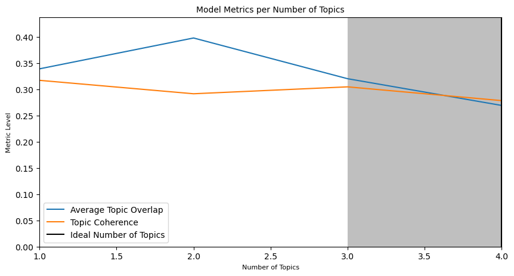

```python
import seaborn as sns
plt.figure(figsize=(10,5))
ax = sns.lineplot(x=num_topics[:-1], y=mean_stabilities, label='Average Topic Overlap')
ax = sns.lineplot(x=num_topics[:-1], y=coherences, label='Topic Coherence')

ax.axvline(x=ideal_topic_num, label='Ideal Number of Topics', color='black')
ax.axvspan(xmin=ideal_topic_num - 1, xmax=ideal_topic_num + 1, alpha=0.5, facecolor='grey')

y_max = max(max(mean_stabilities), max(coherences)) + (0.10 * max(max(mean_stabilities), max(coherences)))
ax.set_ylim([0, y_max])
ax.set_xlim([1, num_topics[-1]-1])

ax.axes.set_title('Model Metrics per Number of Topics', fontsize=10)
ax.set_ylabel('Metric Level', fontsize=8)
ax.set_xlabel('Number of Topics', fontsize=8)
plt.legend(fontsize=10)
plt.show()
```

# #

Your ideal number of topics will maximize coherence and minimize the topic overlap based on Jaccard similarity. In this case it looks like we'd be safe choosing topic numbers around 4.

## Final Optimal LDA Model

```python
# Build LDA model with the optimal number of topics
lda_model = gensim.models.ldamodel.LdaModel(corpus=corpus,
                                           id2word=id2word,
                                           num_topics=4,
                                           random_state=100,
                                           update_every=1,
                                           chunksize=10,
                                           passes=10,
                                           alpha='symmetric',
                                           iterations=100,
                                           per_word_topics=True)

#pprint(lda_model.print_topics())
```

## What is the Dominant topic and its percentage contribution in each document?

```python
def format_topics_sentences(ldamodel=None, corpus=corpus, texts=wana_df['review_clean']):
    # Init output
    sent_topics_df = pd.DataFrame()

    # Get main topic in each document
    for i, row_list in enumerate(ldamodel[corpus]):
        row = row_list[0] if ldamodel.per_word_topics else row_list
        # print(row)
        row = sorted(row, key=lambda x: (x[1]), reverse=True)
        # Get the Dominant topic, Perc Contribution and Keywords for each document
        for j, (topic_num, prop_topic) in enumerate(row):
            if j == 0:  # => dominant topic
                wp = ldamodel.show_topic(topic_num)
                topic_keywords = ", ".join([word for word, prop in wp])
                sent_topics_df = sent_topics_df.append(pd.Series([int(topic_num), round(prop_topic,4), topic_keywords]), ignore_index=True)
            else:
                break
    sent_topics_df.columns = ['Dominant_Topic', 'Perc_Contribution', 'Topic_Keywords']

    # Add original text to the end of the output
    contents = pd.Series(texts)
    sent_topics_df = pd.concat([sent_topics_df, contents], axis=1)
    return(sent_topics_df)


df_topic_sents_keywords = format_topics_sentences(ldamodel=lda_model, corpus=corpus, texts=data_ready)

# Format
df_dominant_topic = df_topic_sents_keywords.reset_index()
df_dominant_topic.columns = ['Document_No', 'Dominant_Topic', 'Topic_Perc_Contrib', 'Keywords', 'Text']
df_dominant_topic
```

|  | Document_No | Dominant_Topic | Topic_Perc_Contrib | Keywords | Text |
| --- | --- | --- | --- | --- | --- |
| 0 | 0 | 1 | 0.7119 | great, taste, relief, relax, work, body, defin... | [mild, great, stress, relief, work] |
| 1 | 1 | 3 | 0.5052 | feel, product, anxiety, cbd, well, really, thc... | [product, really, allow, chill, couple, hour, ... |
| 2 | 2 | 0 | 0.7338 | pain, help, sleep, experience, night, gummy, r... | [multiple, sclerosis, really, help, ease, nerv... |
| 3 | 3 | 2 | 0.7500 | high, gummie, much, first, effect, love, flavo... | [tasty, high] |
| 4 | 4 | 2 | 0.5930 | high, gummie, much, first, effect, love, flavo... | [tastey] |
| ... | ... | ... | ... | ... | ... |
| 625 | 625 | 0 | 0.7191 | pain, help, sleep, experience, night, gummy, r... | [experience, knee, hip, replace, last, couple,... |
| 626 | 626 | 2 | 0.6898 | high, gummie, much, first, effect, love, flavo... | [yummy, able, share, sense, first, never, land... |
| 627 | 627 | 3 | 0.5734 | feel, product, anxiety, cbd, well, really, thc... | [tasty, gummy, mix, predominantly, cbd, pleasa... |
| 628 | 628 | 2 | 0.7500 | high, gummie, much, first, effect, love, flavo... | [tasty, effective] |
| 629 | 629 | 3 | 0.4013 | feel, product, anxiety, cbd, well, really, thc... | [mellow, relax, product, much, high, chill, mo... |

630 rows × 5 columns

## The most representative sentences for each topic

```python
# Display setting to show more characters in column
pd.options.display.max_colwidth = 100

sent_topics_sorteddf_mallet = pd.DataFrame()
sent_topics_outdf_grpd = df_topic_sents_keywords.groupby('Dominant_Topic')

for i, grp in sent_topics_outdf_grpd:
    sent_topics_sorteddf_mallet = pd.concat([sent_topics_sorteddf_mallet,
                                             grp.sort_values(['Perc_Contribution'], ascending=False).head(1)],
                                            axis=0)

# Reset Index
sent_topics_sorteddf_mallet.reset_index(drop=True, inplace=True)

# Format
sent_topics_sorteddf_mallet.columns = ['Topic_Num', "Topic_Perc_Contrib", "Keywords", "Representative Text"]

# Show
sent_topics_sorteddf_mallet
```

|  | Topic_Num | Topic_Perc_Contrib | Keywords | Representative Text |
| --- | --- | --- | --- | --- |
| 0 | 0 | 0.9419 | pain, help, sleep, experience, night, gummy, relaxed, little, mood, half | [sickle, cell, anemia, pain, crisis, episode, increase, help, relieve, pain, allow, sleep] |
| 1 | 1 | 0.9055 | great, taste, relief, relax, work, body, definitely, enough, day, stock | [great, head, buzz, keep, body, light, relax] |
| 2 | 2 | 0.9051 | high, gummie, much, first, effect, love, flavor, tolerance, hour, tasty | [flavor, variety, pack, gummie, tasty, consistently, bake] |
| 3 | 3 | 0.9049 | feel, product, anxiety, cbd, well, really, thc, time, back, eat | [heighten, joy, listen, play, music, drink, water] |

Oberservation:

1. Topic 0 is about helping sleep at night i.e feeling relaxed
2. Topic 1 is about great taste
3. Topic 2 is about a good high and flavour
4. Topic 3 is about Anxiety (not sure if it reduces or increases)

## Frequency Distribution of Word Counts in Documents

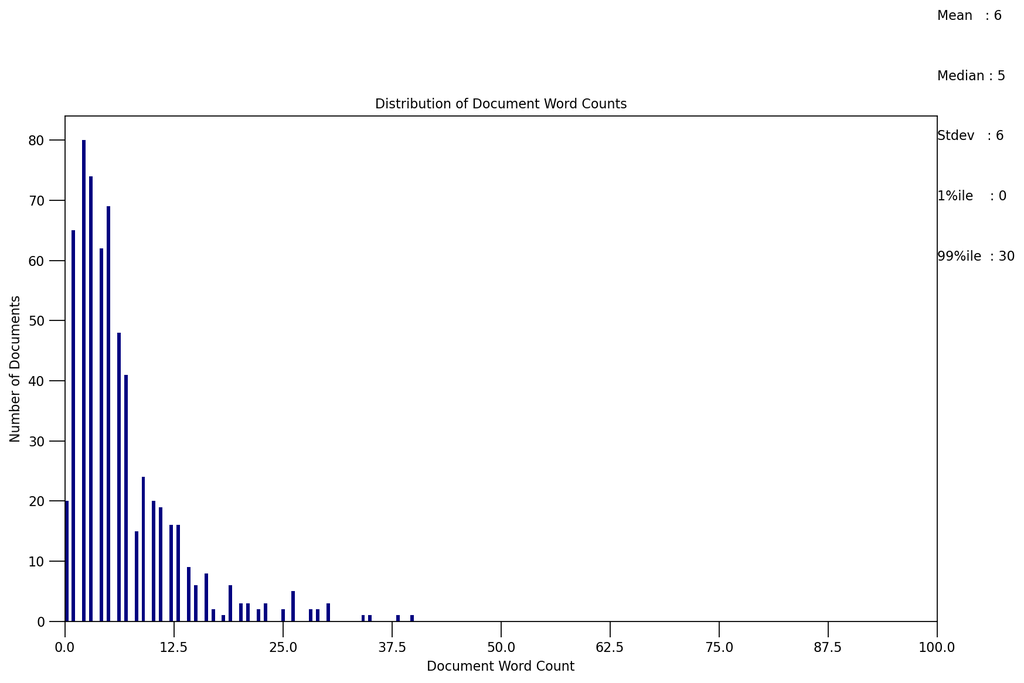

```python
doc_lens = [len(d) for d in df_dominant_topic.Text]

# Plot
plt.figure(figsize=(12,7), dpi=160)
plt.hist(doc_lens, bins = 100, color='navy')
plt.text(100, 100, "Mean   : " + str(round(np.mean(doc_lens))))
plt.text(100,  90, "Median : " + str(round(np.median(doc_lens))))
plt.text(100,  80, "Stdev   : " + str(round(np.std(doc_lens))))
plt.text(100,  70, "1%ile    : " + str(round(np.quantile(doc_lens, q=0.01))))
plt.text(100,  60, "99%ile  : " + str(round(np.quantile(doc_lens, q=0.99))))

plt.gca().set(xlim=(0, 100), ylabel='Number of Documents', xlabel='Document Word Count')
plt.tick_params(size=12)
plt.xticks(np.linspace(0,100,9))
plt.title('Distribution of Document Word Counts', fontdict=dict(size=10))
plt.show()
```

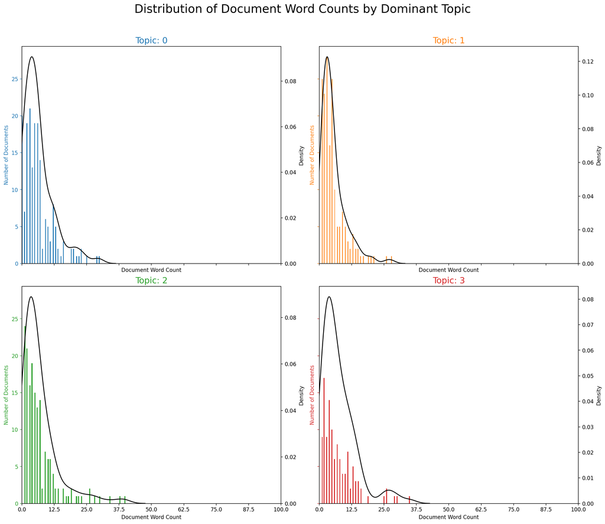

```python
import seaborn as sns
import matplotlib.colors as mcolors
cols = [color for name, color in mcolors.TABLEAU_COLORS.items()]  # more colors: 'mcolors.XKCD_COLORS'

fig, axes = plt.subplots(2,2,figsize=(16,14), dpi=160, sharex=True, sharey=True)

for i, ax in enumerate(axes.flatten()):
    df_dominant_topic_sub = df_dominant_topic.loc[df_dominant_topic.Dominant_Topic == i, :]
    doc_lens = [len(d) for d in df_dominant_topic_sub.Text]
    ax.hist(doc_lens, bins = 100, color=cols[i])
    ax.tick_params(axis='y', labelcolor=cols[i], color=cols[i])
    sns.kdeplot(doc_lens, color="black", shade=False, ax=ax.twinx())
    ax.set(xlim=(0, 100), xlabel='Document Word Count')
    ax.set_ylabel('Number of Documents', color=cols[i])
    ax.set_title('Topic: '+str(i), fontdict=dict(size=16, color=cols[i]))

fig.tight_layout()
fig.subplots_adjust(top=0.90)
plt.xticks(np.linspace(0,100,9))
fig.suptitle('Distribution of Document Word Counts by Dominant Topic', fontsize=22)
plt.show()
```

```python
#pip install wordcloud
```

## Word Clouds of Top N Keywords in Each Topic

# #

We have already viewed the topic keywords for each topic, it can be visually pleasing to observe a word cloud where the size of the words corresponds to their weight. Additionally, the subsequent plots will follow the same color scheme as the one used for the topics in question.

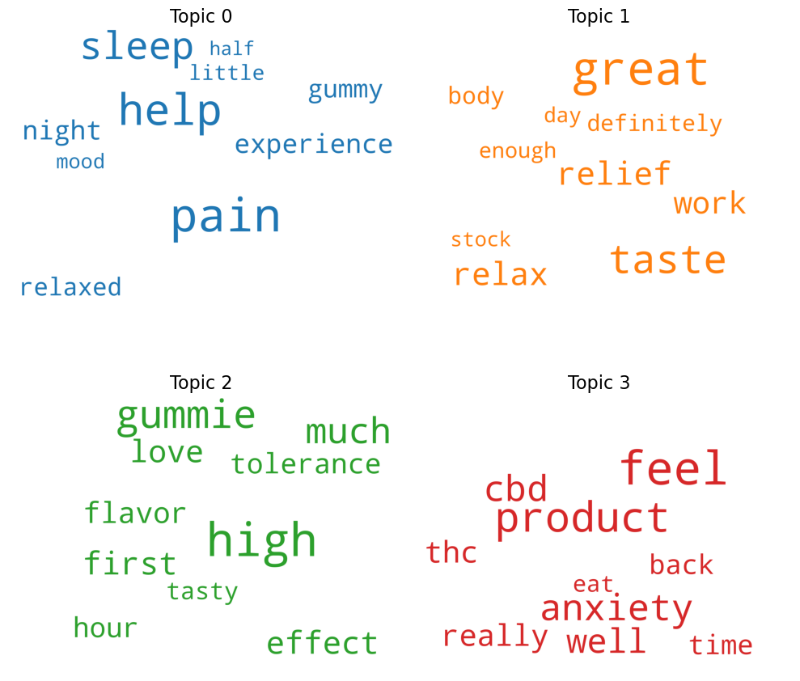

```python
# 1. Wordcloud of Top N words in each topic
from matplotlib import pyplot as plt
from wordcloud import WordCloud, STOPWORDS
import matplotlib.colors as mcolors

cols = [color for name, color in mcolors.TABLEAU_COLORS.items()]  # more colors: 'mcolors.XKCD_COLORS'

cloud = WordCloud(stopwords=stop_words,
                  background_color='white',
                  width=2500,
                  height=1800,
                  max_words=10,
                  colormap='tab10',
                  color_func=lambda *args, **kwargs: cols[i],
                  prefer_horizontal=1.0)

topics = lda_model.show_topics(formatted=False)

fig, axes = plt.subplots(2, 2, figsize=(10,10), sharex=True, sharey=True)

for i, ax in enumerate(axes.flatten()):
    fig.add_subplot(ax)
    topic_words = dict(topics[i][1])
    cloud.generate_from_frequencies(topic_words, max_font_size=300)
    plt.gca().imshow(cloud)
    plt.gca().set_title('Topic ' + str(i), fontdict=dict(size=16))
    plt.gca().axis('off')


plt.subplots_adjust(wspace=0, hspace=0)
plt.axis('off')
plt.margins(x=0, y=0)
plt.tight_layout()
plt.show()
```

Conclusion about the topics:

1. Topic 0: Helps sleep and relieve pain
2. Topic 1: Helps relax and great taste
3. Topic 2: Good high and Flavorful
4. Topic 3: Anxiety

## Word Counts of Topic Keywords

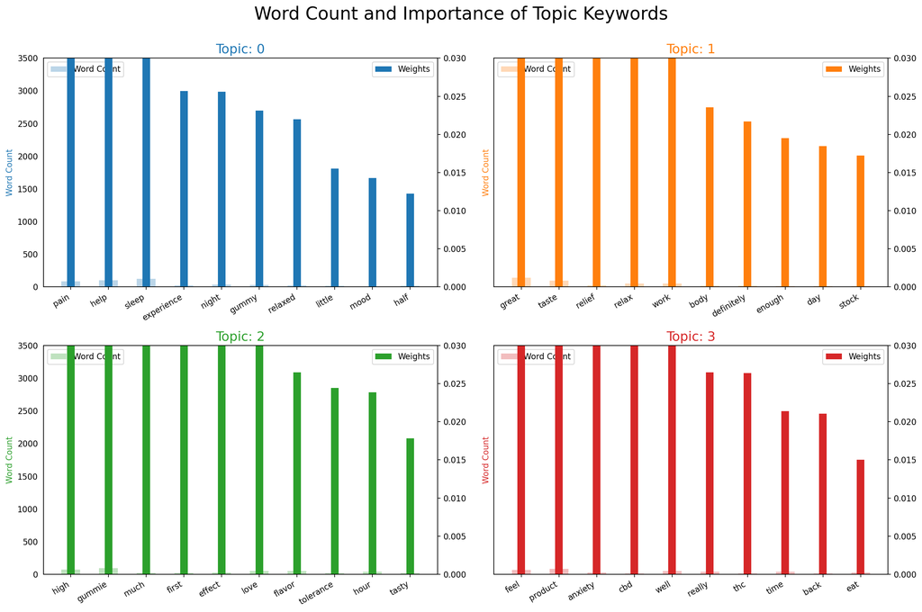

```python
from collections import Counter
topics = lda_model.show_topics(formatted=False)
data_flat = [w for w_list in data_ready for w in w_list]
counter = Counter(data_flat)

out = []
for i, topic in topics:
    for word, weight in topic:
        out.append([word, i , weight, counter[word]])

df = pd.DataFrame(out, columns=['word', 'topic_id', 'importance', 'word_count'])

# Plot Word Count and Weights of Topic Keywords
fig, axes = plt.subplots(2, 2, figsize=(16,10), sharey=True, dpi=160)
cols = [color for name, color in mcolors.TABLEAU_COLORS.items()]
for i, ax in enumerate(axes.flatten()):
    ax.bar(x='word', height="word_count", data=df.loc[df.topic_id==i, :], color=cols[i], width=0.5, alpha=0.3, label='Word Count')
    ax_twin = ax.twinx()
    ax_twin.bar(x='word', height="importance", data=df.loc[df.topic_id==i, :], color=cols[i], width=0.2, label='Weights')
    ax.set_ylabel('Word Count', color=cols[i])
    ax_twin.set_ylim(0, 0.030); ax.set_ylim(0, 3500)
    ax.set_title('Topic: ' + str(i), color=cols[i], fontsize=16)
    ax.tick_params(axis='y', left=False)
    ax.set_xticklabels(df.loc[df.topic_id==i, 'word'], rotation=30, horizontalalignment= 'right')
    ax.legend(loc='upper left'); ax_twin.legend(loc='upper right')

fig.tight_layout(w_pad=2)
fig.suptitle('Word Count and Importance of Topic Keywords', fontsize=22, y=1.05)
plt.show()
```

Oberservation: Similar results to the previous one

1. Topic 0 is about helping sleep at night i.e feeling relaxed
2. Topic 1 is about great taste
3. Topic 2 is about a good high and flavour of the gummie
4. Topic 3 is about Anxiety (not sure if it reduces or increases)

1. Number of documents for each topic by assigning the document to the topic that has the most weight in that document.

```python
# Sentence Coloring of N Sentences
from matplotlib.patches import Rectangle

def sentences_chart(lda_model=lda_model, corpus=corpus, start = 0, end = 13):
    corp = corpus[start:end]
    mycolors = [color for name, color in mcolors.TABLEAU_COLORS.items()]

    fig, axes = plt.subplots(end-start, 1, figsize=(20, (end-start)*0.95), dpi=160)
    axes[0].axis('off')
    for i, ax in enumerate(axes):
        if i > 0:
            corp_cur = corp[i-1]
            topic_percs, wordid_topics, wordid_phivalues = lda_model[corp_cur]
            word_dominanttopic = [(lda_model.id2word[wd], topic[0]) for wd, topic in wordid_topics]
            ax.text(0.01, 0.5, "Doc " + str(i-1) + ": ", verticalalignment='center',
                    fontsize=16, color='black', transform=ax.transAxes, fontweight=700)

            # Draw Rectange
            topic_percs_sorted = sorted(topic_percs, key=lambda x: (x[1]), reverse=True)
            ax.add_patch(Rectangle((0.0, 0.05), 0.99, 0.90, fill=None, alpha=1,
                                   color=mycolors[topic_percs_sorted[0][0]], linewidth=2))

            word_pos = 0.06
            for j, (word, topics) in enumerate(word_dominanttopic):
                if j < 14:
                    ax.text(word_pos, 0.5, word,
                            horizontalalignment='left',
                            verticalalignment='center',
                            fontsize=16, color=mycolors[topics],
                            transform=ax.transAxes, fontweight=700)
                    word_pos += .009 * len(word)  # to move the word for the next iter
                    ax.axis('off')
            ax.text(word_pos, 0.5, '. . .',
                    horizontalalignment='left',
                    verticalalignment='center',
                    fontsize=16, color='black',
                    transform=ax.transAxes)

    plt.subplots_adjust(wspace=0, hspace=0)
    plt.suptitle('Sentence Topic Coloring for Documents: ' + str(start) + ' to ' + str(end-2), fontsize=22, y=0.95, fontweight=700)
    plt.tight_layout()
    plt.show()
```

1. Number of documents for each topic by by summing up the actual weight contribution of each topic to respective documents.

```python
# Sentence Coloring of N Sentences
def topics_per_document(model, corpus, start=0, end=1):
    corpus_sel = corpus[start:end]
    dominant_topics = []
    topic_percentages = []
    for i, corp in enumerate(corpus_sel):
        topic_percs, wordid_topics, wordid_phivalues = model[corp]
        dominant_topic = sorted(topic_percs, key = lambda x: x[1], reverse=True)[0][0]
        dominant_topics.append((i, dominant_topic))
        topic_percentages.append(topic_percs)
    return(dominant_topics, topic_percentages)

dominant_topics, topic_percentages = topics_per_document(model=lda_model, corpus=corpus, end=-1)

# Distribution of Dominant Topics in Each Document
df = pd.DataFrame(dominant_topics, columns=['Document_Id', 'Dominant_Topic'])
dominant_topic_in_each_doc = df.groupby('Dominant_Topic').size()
df_dominant_topic_in_each_doc = dominant_topic_in_each_doc.to_frame(name='count').reset_index()

# Total Topic Distribution by actual weight
topic_weightage_by_doc = pd.DataFrame([dict(t) for t in topic_percentages])
df_topic_weightage_by_doc = topic_weightage_by_doc.sum().to_frame(name='count').reset_index()

# Top 3 Keywords for each Topic
topic_top3words = [(i, topic) for i, topics in lda_model.show_topics(formatted=False)
                                 for j, (topic, wt) in enumerate(topics) if j < 3]

df_top3words_stacked = pd.DataFrame(topic_top3words, columns=['topic_id', 'words'])
df_top3words = df_top3words_stacked.groupby('topic_id').agg(', \n'.join)
df_top3words.reset_index(level=0,inplace=True)
```

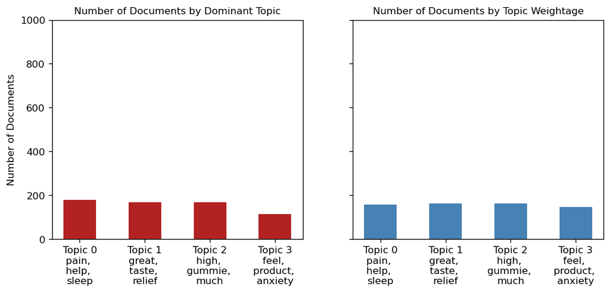

```python
from matplotlib.ticker import FuncFormatter

# Plot
fig, (ax1, ax2) = plt.subplots(1, 2, figsize=(10, 4), dpi=120, sharey=True)

# Topic Distribution by Dominant Topics
ax1.bar(x='Dominant_Topic', height='count', data=df_dominant_topic_in_each_doc, width=.5, color='firebrick')
ax1.set_xticks(range(df_dominant_topic_in_each_doc.Dominant_Topic.unique().__len__()))
tick_formatter = FuncFormatter(lambda x, pos: 'Topic ' + str(x)+ '\n' + df_top3words.loc[df_top3words.topic_id==x, 'words'].values[0])
ax1.xaxis.set_major_formatter(tick_formatter)
ax1.set_title('Number of Documents by Dominant Topic', fontdict=dict(size=10))
ax1.set_ylabel('Number of Documents')
ax1.set_ylim(0, 1000)

# Topic Distribution by Topic Weights
ax2.bar(x='index', height='count', data=df_topic_weightage_by_doc, width=.5, color='steelblue')
ax2.set_xticks(range(df_topic_weightage_by_doc.index.unique().__len__()))
ax2.xaxis.set_major_formatter(tick_formatter)
ax2.set_title('Number of Documents by Topic Weightage', fontdict=dict(size=10))

plt.show()
```

## t-SNE Clustering Chart

```python
# Get topic weights and dominant topics ------------
from sklearn.manifold import TSNE
from bokeh.plotting import figure, output_file, show
from bokeh.models import Label
from bokeh.io import output_notebook

# Get topic weights
topic_weights = []
for i, row_list in enumerate(lda_model[corpus]):
    topic_weights.append([w for i, w in row_list[0]])

# Array of topic weights
arr = pd.DataFrame(topic_weights).fillna(0).values

# Keep the well separated points (optional)
arr = arr[np.amax(arr, axis=1) > 0.35]

# Dominant topic number in each doc
topic_num = np.argmax(arr, axis=1)

# tSNE Dimension Reduction
tsne_model = TSNE(n_components=2, verbose=1, random_state=0, angle=.99, init='pca')
tsne_lda = tsne_model.fit_transform(arr)

# Plot the Topic Clusters using Bokeh
output_notebook()
n_topics = 4
mycolors = np.array([color for name, color in mcolors.TABLEAU_COLORS.items()])
plot = figure(title="t-SNE Clustering of {} LDA Topics".format(n_topics),
              plot_width=900, plot_height=700)
plot.scatter(x=tsne_lda[:,0], y=tsne_lda[:,1], color=mycolors[topic_num])
show(plot)
```

```
[t-SNE] Computing 91 nearest neighbors...
[t-SNE] Indexed 580 samples in 0.000s...
[t-SNE] Computed neighbors for 580 samples in 0.025s...
[t-SNE] Computed conditional probabilities for sample 580 / 580
[t-SNE] Mean sigma: 0.101778
[t-SNE] KL divergence after 250 iterations with early exaggeration: 57.692238
[t-SNE] KL divergence after 950 iterations: 0.412383
```

[interactive chart not shown]

Observation:

1. We see 4 different clusters, indicating 4 main topics
2. There are a few outliers in every cluster
3. The orange cluster is very close to green and blue indicating a little relatedness
4. Some words may appear in more than one cluster, indicating that they are polysemous or have multiple meanings.

## pyLDAVis Visualization

```python
import pyLDAvis.gensim_models
pyLDAvis.enable_notebook()
vis = pyLDAvis.gensim_models.prepare(lda_model, corpus, dictionary=lda_model.id2word)
vis
```

[interactive chart not shown]

The LDA analysis shows that there is no overlap in the topics on the left. One the right hand side we can see the salient features related to the topics. However, LDA analysis doesnt help us identify the topics, hence we have have to perform word count, weighted topic reprsentation to identify the topics. Summarizing the topics that have been identified from the above analysis follows:

1. Topic 0: Helps sleep and relieve pain
2. Topic 1: Helps relax and great taste
3. Topic 2: Good high and Flavorful
4. Topic 3: Anxiety

```python
pyLDAvis.save_html(vis, 'lda.html')
```

In case the pyLDAVis Visualization is not visible -

1. I have uploaded the html version of the lda results
2. Download the file in your laptop for viewing
3. Look at the HTML version of the code